# Untitled

2023-11-13

## #load packages

library(SpatialExperiment)

library(STexampleData)

library(scater)

library(ggspavis)

#Load data:

spe <- readRDS(“C:/Users/sanaz/OneDrive/Documents/cosmx_lung_5_rep1_SPE.RDS”)

dim(spe)

#980 100292

#head(colData(spe))

#Histogram:

par(mfrow=c(2,2))

hist(colData(spe)$Width, breaks = 20)

hist(colData(spe)$Height, breaks = 20)

hist(colData(spe)$Mean.PanCK, breaks = 20)

hist(colData(spe)$Mean.DAPI, breaks = 20)

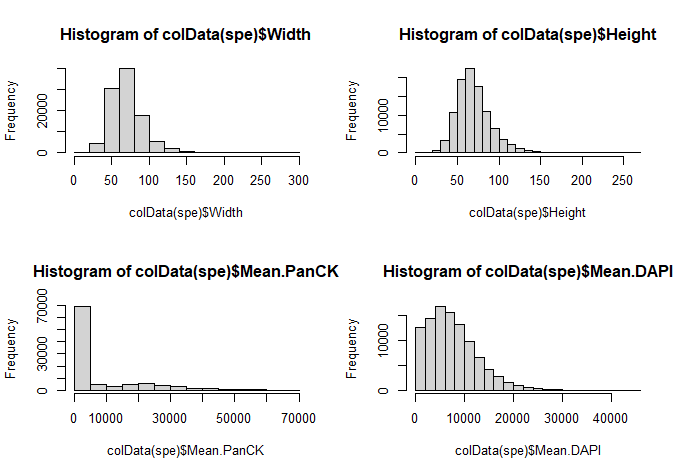

[figure not shown]

# Selecting thresholds

# Thresholds for Width

#Histogram for width

par(mfrow=c(1,1))

hist(colData(spe)$Width, breaks = 20)

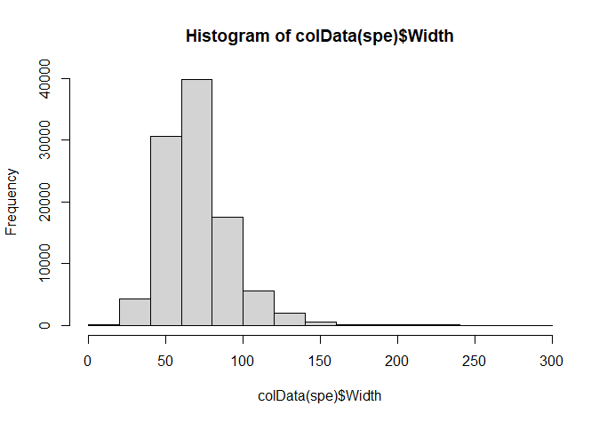

plotQC(spe, type = “scatter”,

metric_x = “Area”, metric_y = “Width”,

threshold_y = 200)

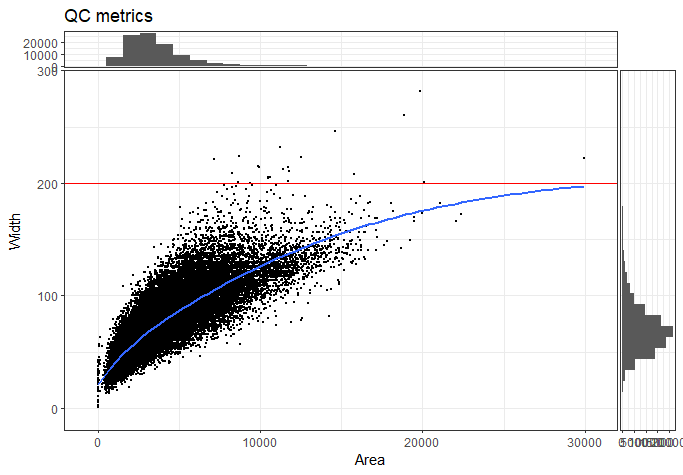

qc_Width = colData(spe)$Width > 200

table(qc_Width)

#FALSE TRUE

#100271 21

colData(spe)$qc_Width = qc_Width

plotQC(spe, type = “spots”,in_tissue = NULL,discard = “qc_Width”)

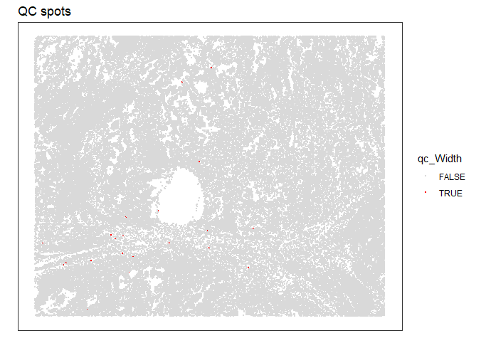

qc_width_150 = colData(spe)$Width > 150

colData(spe)$qc_width_150 = qc_width_150

plotQC(spe, type = “spots”, in_tissue = NULL, discard = “qc_width_150”)

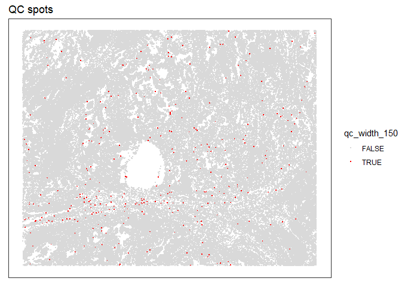

plotSpots(spe, annotate = NULL,in_tissue = NULL, palette = “libd_layer_colors”)

#Thresholds for Height

#Histogram:

hist(colData(spe)$Height, breaks = 20)

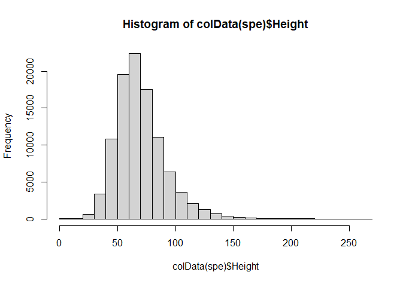

plotQC(spe, type = “scatter”,

metric_x = “Area”, metric_y = “Height”,

threshold_y = 200)

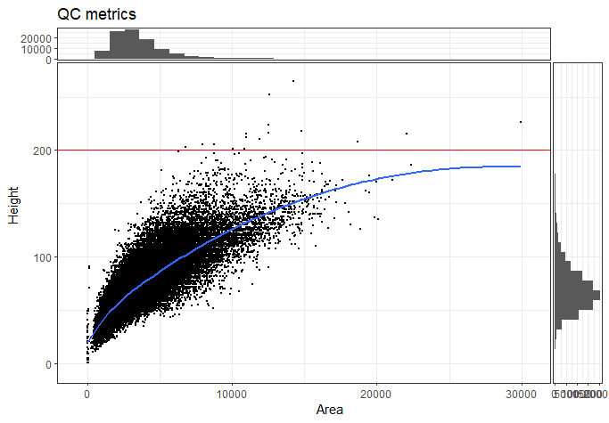

qc_Height = colData(spe)$Height > 200

table(qc_Height)

#FALSE TRUE  
#100276 16

colData(spe)$qc_Height = qc_Height

plotQC(spe, type = “spots”,in_tissue = NULL,discard = “qc_Height”)

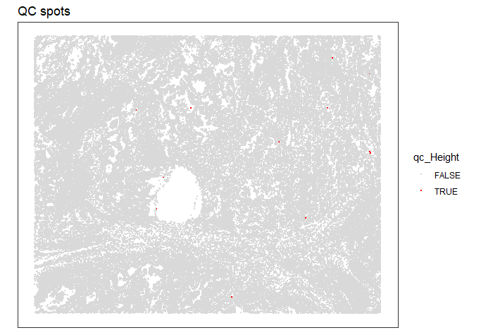

qc_Height_150 = colData(spe)$Height > 150

colData(spe)$qc_Height_150 = qc_Height_150

plotQC(spe, type = “spots”, in_tissue = NULL, discard = “qc_Height_150”)

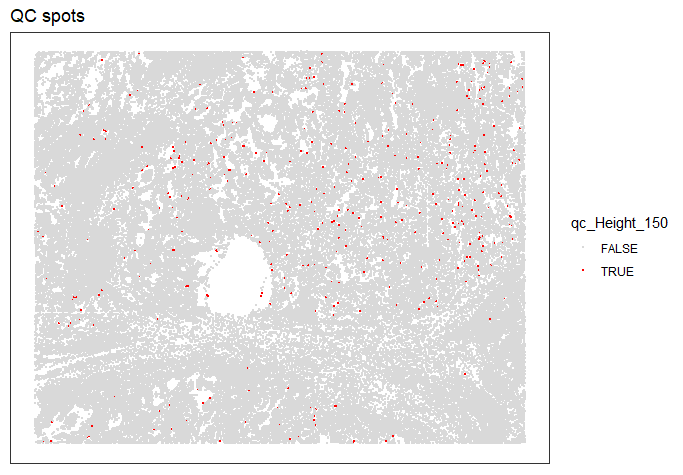

plotSpots(spe, annotate = NULL,in_tissue = NULL, palette = “libd_layer_colors”)

# Thresholds for Mean.PanCK

#Histogram:

hist(colData(spe)$Mean.PanCK, breaks = 20)

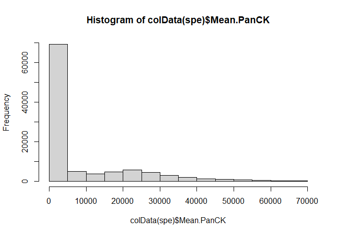

plotQC(spe, type = “scatter”,

metric_x = “Area”, metric_y = “Mean.PanCK”,

threshold_y = 60000)

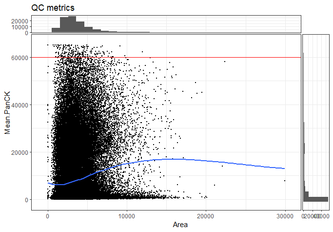

qc_Mean.PanCK = colData(spe)$Mean.PanCK > 60000

table(qc_Mean.PanCK)

#FALSE TRUE  
#100056 236

colData(spe)$qc_Mean.PanCK = qc_Mean.PanCK

plotQC(spe, type = “spots”,in_tissue = NULL,discard = “qc_Mean.PanCK”)

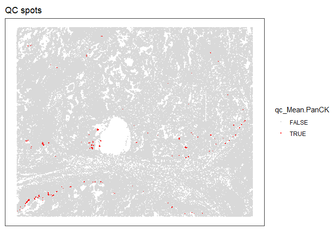

qc_Mean.PanCK_50000 = colData(spe)$Mean.PanCK > 50000

colData(spe)$qc_Mean.PanCK_50000 = qc_Mean.PanCK_50000

plotQC(spe, type = “spots”, in_tissue = NULL, discard = “qc_Mean.PanCK_50000”)

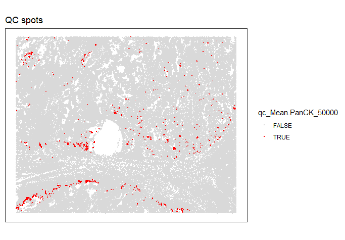

plotSpots(spe, annotate = NULL,in_tissue = NULL, palette = “libd_layer_colors”)

# Thresholds for Mean.DAPI

#Histogram:

hist(colData(spe)$Mean.DAPI, breaks = 20)

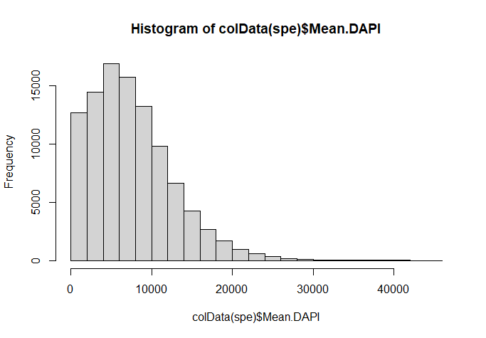

plotQC(spe, type = “scatter”,

metric_x = “Area”, metric_y = “Mean.DAPI”,

threshold_y = 30000)

[figure not shown]

qc_Mean.DAPI = colData(spe)$Mean.DAPI > 30000

table(qc_Mean.DAPI)

#FALSE TRUE  
#100181 111

colData(spe)$qc_Mean.DAPI = qc_Mean.DAPI

plotQC(spe, type = “spots”,in_tissue = NULL,discard = “qc_Mean.DAPI”)

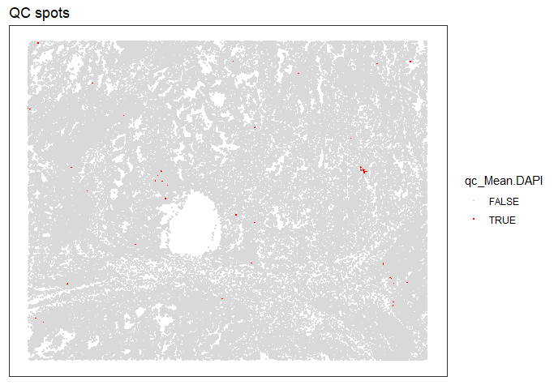

qc_Mean.DAPI_20000 = colData(spe)$Mean.DAPI > 20000

colData(spe)$qc_Mean.DAPI_20000 = qc_Mean.DAPI_20000

plotQC(spe, type = “spots”, in_tissue = NULL, discard = “qc_Mean.DAPI_20000”)

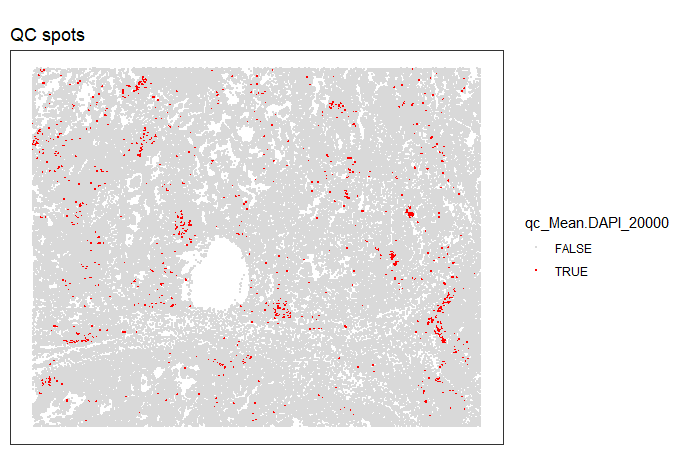

plotSpots(spe, annotate = NULL,in_tissue = NULL, palette = “libd_layer_colors”)

# Remove low-quality spots

apply(cbind(qc_Width, qc_Height, qc_Mean.PanCK, qc_Mean.DAPI), 2, sum)

discard = qc_Width | qc_Height | qc_Mean.PanCK | qc_Mean.DAPI

table(discard)

#FALSE TRUE

#99909 383

colData(spe)$discard = discard

plotQC(spe, type = “spots”,in_tissue = NULL,discard = “discard”)

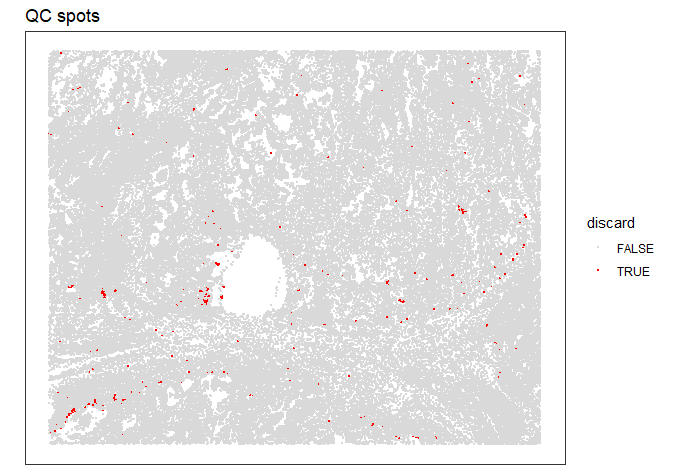

spe = spe[, !colData(spe)$discard]

dim(spe)

#980 99909

# Zero-cell and single-cell spots

tbl_cells_per_spot = table(colData(spe)$Area)

tbl_cells_per_spot[1:13]

prop_cells_per_spot = round(tbl_cells_per_spot / sum(tbl_cells_per_spot), 2)

prop_cells_per_spot[1:13]

# **Normalization**

#**Removing any spots with non-positive counts:**

spe = spe[, colSums(counts(spe)) > 0]

#**Calculate library size factors:**

spe <- computeLibraryFactors(spe)

summary(sizeFactors(spe))

hist(sizeFactors(spe), breaks = 20)

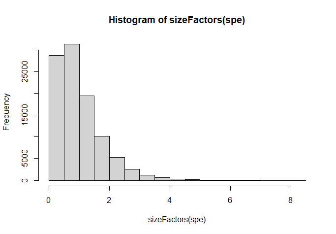

#C**alculate logcounts and store in object:**

spe <- logNormCounts(spe)

#**Check:**

assayNames(spe)

dim(counts(spe))

dim(logcounts(spe))

# **Feature selection**

#**Fit mean-variance relationship:**

library(scran)library(scran)

dec = modelGeneVar(spe)

fit = metadata(dec)

#visualize mean-variance relationship:

plot(fit$mean, fit$var,

xlab = “mean of log-expression”, ylab = “variance of log-expression”)

curve(fit$trend(x), col = “dodgerblue”, add = TRUE, lwd = 2)

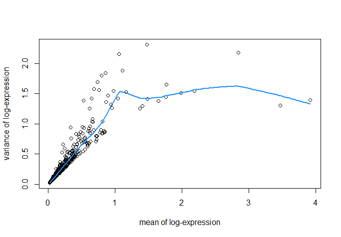

#Select top HVGs

top_hvgs = getTopHVGs(dec, prop = 0.1)

length(top_hvgs)

#65

# **Dimensionality reduction**

**#Compute PCA:**

set.seed(123)

spe = runPCA(spe, subset_row = top_hvgs)

reducedDimNames(spe)

dim(reducedDim(spe, “PCA”))

#Compute UMAP on top 50 PCs:

set.seed(123)

spe = runUMAP(spe, dimred = “PCA”)

reducedDimNames(spe)

dim(reducedDim(spe, “UMAP”))

#Update column names for easier plotting:

colnames(reducedDim(spe, “UMAP”)) = paste0(“UMAP”, 1:2)

#**Plot top 2 PCA dimensions:**

plotDimRed(spe, type = “PCA”)

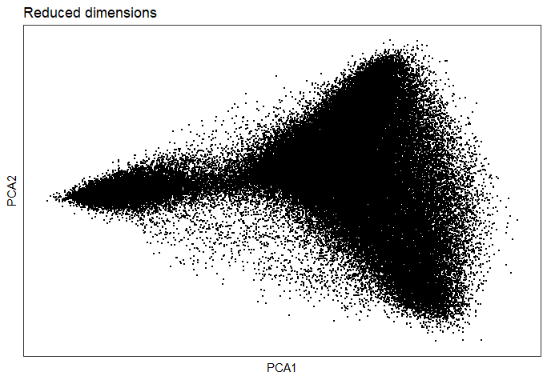

#**Plot top 2 UMAP dimensions:**

plotDimRed(spe, type = “UMAP”)

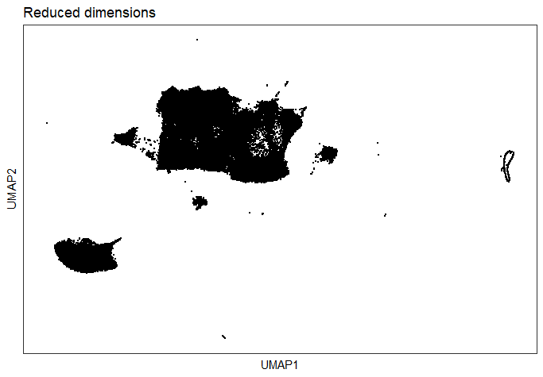

# **# Clustering**

**spe1 is a Subset of data for clustering:**

spe1=spe[1:200,1:10000]

#Graph-based clustering:

set.seed(123)

k =10

g = buildSNNGraph(spe1, k = k, use.dimred = “PCA”)

g_walk = igraph::cluster_walktrap(g)

clus = g_walk$membership

table(clus)

#Store cluster labels in column ‘label’ in colData:

colLabels(spe1) = factor(clus)

##Plot clusters in spatial x-y coordinates:

plotSpots(spe1, annotate = colData(spe1)$label,

palette = “libd_layer_colors”,in_tissue = NULL)

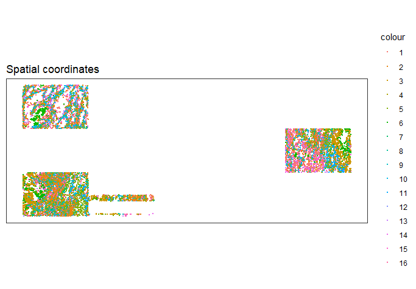

plotDimRed(spe1, type = “PCA”,

annotate = NULL, palette = “libd_layer_colors”)

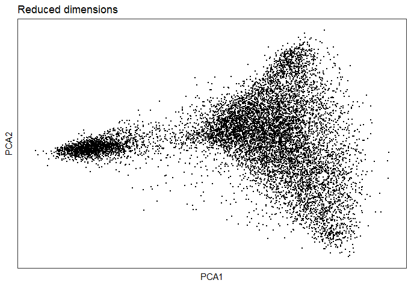

#Plot clusters in UMAP reduced dimensions

spe1=spe[1:200,1:10000]

colLabels(spe1) = factor(clus)

plotDimRed(spe1, type = “UMAP”,

annotate = colData(spe1)$label, palette = “libd_layer_colors”)

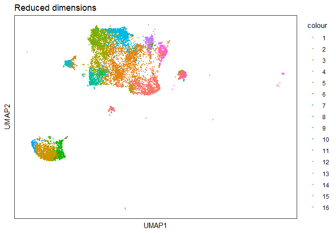